Econometrics and Statistics (520K)

# Econometric Methods in Business and Economics

Practical Class (Winter 24/25)

by Domenic Franjic

# Exercise Sheet No 06

Linear Regression with Multiple Regressors (Part 2)

## Set-Up

1) Create your (working) directory

Create a new folder on your computer in which you can save all necessary files, i.e., the data set, the R *script* with the implementation of your analysis and the R *helper function script* with some helper functions provided by us.

This folder, i.e., the path or directory of this folder, will be your so-called working directory.

2) Download the data set

Download the data set `CASchools_03_data.txt` from ILIAS directly or by using the link below:

[Download `CASchools_03_data.txt`](https://ilias.uni-hohenheim.de/goto.php?target=file_1538158_download&client_id=UHOH)

Save the data set into a (working) directory of your choice.

3) Prepare *script*

Open a new R *script* and save it into into your (working) directory.

Run the following code chunk to prepare your R *script*, i.e., to clear the work space and set your working directory.

```r
# Clear workspace
rm(list = ls(all = TRUE))
# Set working directory
setwd(".../set/your/working/directory/...")
```

4) Install/load *packages* and download/save/include *helper function script*

Step 1) Install all relevant R *packages* and download and save the R *script* `r_helper_functions.R` from ILIAS by running the following code chunk.

```r
# Download R-helper functions
source("https://ilias.uni-hohenheim.de/data/UHOH/lm_data/lm_1856939/MA_EconometricMethods_WiSe2324_PracticalClass/r-scripts/prepare_r_packages_and_helper_functions.R")
```

*Note*, the required R *packages* are `"moments"`, `"sandwich"`, `"lmtest"`, `"lmtest"`, `"car"`, `"plm"`, `"ivreg"`, `"dynlm"`, `"forecast"`, `"urca"`.

Step 2) Include the R *script* `r_helper_functions.R` into your R *script* by running the following code chunk.

```r
# Include R-helper functions
source("r_helper_functions.R")
```

*Note*, more information on the helper functions can be found here.

## Preparations

Load data, construct variables and estimation results.

Variables

| Variable | Description |
| --- | --- |
| $students$ | Total enrollment. |
| $teachers$ | Number of teachers. |
| $read$ | Average reading score. |
| $math$ | Average math score. |
| $PctEL$ | Percent of English learners. |
| $Expen$ | Expenditure per student. |

Load data set

```r
# use absolute or relative path to load data
cas.dat <- read.table(file = "CASchools_03_data.txt",
                      header = TRUE,
                      sep = ",")
```

Construct variables

```r
# compute STR and append it to cas.dat
cas.dat$STR <- cas.dat$students/cas.dat$teachers
# compute TestScore and append it to cas.dat
cas.dat$score <- (cas.dat$read + cas.dat$math)/2
```

## Task 1

Class size and student performance

We return to our analysis of class size and student performance. For this we use the complete California test score data set `CASchool_03_data.txt` and focus on the two variables $test score$ and $STR$ as obtained in the first exercise sheet again.

### Task a)

Load the data set into your favorite statistics software. Re-code $STR$ into a binary variable for small ($STR \leq 20$) and large class sizes ($STR > 20$) again and replicate and interpret the regression results depicted in Table 1 of the exercise sheet.

Re-code $\underline{STR}$

```r
# re-coding of STR into binary variable
cas.dat$small <- round(cas.dat$STR,2)<20
```

Regression results

```r
# model 1
lm.ct.res.01 <- lm_ct_fun(score ~ STR, data=cas.dat, hc.type="HC1")
lm.ct.res.01$ct
# model 2
lm.ct.res.02 <- lm_ct_fun(score ~ small, data=cas.dat, hc.type="HC1")
lm.ct.res.02$ct
# model 3
lm.ct.res.03 <- lm_ct_fun(score ~ STR + small, data=cas.dat, hc.type="HC1")
lm.ct.res.03$ct
```

```
##
## t test of coefficients:
##
##              Estimate Std. Error t value  Pr(>|t|)
## (Intercept) 698.93295   10.36436 67.4362 < 2.2e-16 ***
## STR          -2.27981    0.51949 -4.3886 1.447e-05 ***
## ---
## Signif. codes:  0 '***' 0.001 '**' 0.01 '*' 0.05 '.' 0.1 ' ' 1
```

```
##
## t test of coefficients:
##
##             Estimate Std. Error  t value  Pr(>|t|)
## (Intercept) 649.9788     1.3229 491.3317 < 2.2e-16 ***
## smallTRUE     7.3724     1.8236   4.0428 6.288e-05 ***
## ---
## Signif. codes:  0 '***' 0.001 '**' 0.01 '*' 0.05 '.' 0.1 ' ' 1
```

```
##
## t test of coefficients:
##
##              Estimate Std. Error t value Pr(>|t|)
## (Intercept) 690.83563   16.92498 40.8175   <2e-16 ***
## STR          -1.91964    0.79209 -2.4235   0.0158 *
## smallTRUE     1.80603    2.77126  0.6517   0.5150
## ---
## Signif. codes:  0 '***' 0.001 '**' 0.01 '*' 0.05 '.' 0.1 ' ' 1
```

```
##
## ==========================================================================
##            Model 1               Model 2              Model 3
## --------------------------------------------------------------------------
## intercept  698.933 (10.364) ***  649.979 (1.323) ***  690.836 (16.925) ***
## STR         -2.280  (0.519) ***                        -1.920  (0.792) *
## small                              7.372 (1.824) ***    1.806  (2.771)
## --------------------------------------------------------------------------
## R^2          0.051                 0.037                0.052
## Adj. R^2     0.049                 0.035                0.048
## Num. obs.  420                   420                  420
## SER         18.581                18.721               18.594
## ==========================================================================
## *** p < 0.001; ** p < 0.01; * p < 0.05
```

Interpretation

*Add your results here!*

### Task b)

Compare the three regression model w.r.t. to their fitting.

Comparison w.r.t. fitting

- $R^2$: Model 3 has (necessarily) the best fit w.r.t. $R^2$.
- $\overline{R}^2$: Model 1 has the best fit w.r.t. $\overline{R}^2$.
- $SER$: Model 1 has the best fit w.r.t. $SER$.
- Adding the variable $small$ after using $STR$ improves the fitting only marginally and thus, not enough to be justified by $\overline{R}^2$ and $SER$.

Remember

$$SER = s_{\widehat{u}} =
\sqrt{s_{\widehat{u}}^2} \ \ \ \text{where} \ \ \ s_{\widehat{u} }^2 =
\frac{1}{n - k - 1} \sum_{i = 1}^n \hat{u}^2_i = \frac{SSR}{n - k - 1}$$

*Add your results here!*

### Task c)

Compare the three regression model w.r.t. the effect of class size on student performance.

Interpretation

- Model 1 and Model 2: There is a significant (negative) effect of class size on student performance.
- Model 3: Less significant (negative) effect of $STR$ after accounting for a regression line shift for small classes. ($\Rightarrow$ Problem of imperfect multicolinearity!)

*Add your results here!*

### Task d)

Discuss regression model three w.r.t. multicollinearity.

Interpretation

- The variables $STR$ and $small$ are related as $small$ is constructed based on $STR$.
- Though, this relationship is not linear but non-linear due to the “threshold” at $STR=20$.
- Still, both variables capture information about class size.
- As a results the estimated coefficients are estimated more imprecise.

*Add your results here!*

## Task 2

Expenditure per pupil and student performance

We now focus on the analysis of expenditure per pupil and student performance. For this we use again the complete California test score data set `CASchool_02_data.csv` and focus on the two variables $test score$, $STR$ (both as obtained in the first exercise sheet), $PctEL$ and $Expn$.

### Task a)

Replicate and interpret the regression results depicted in Table 2 of the exercise sheet.

Regression estimation

```r
# model 4
lm.ct.res.04 <- lm_ct_fun(score ~ STR + PctEL + Expn, data = cas.dat, hc.type="HC1")
lm.ct.res.04$ct
```

```
##
## t test of coefficients:
##
##                Estimate  Std. Error  t value Pr(>|t|)
## (Intercept) 649.5779466  15.4583437  42.0212  < 2e-16 ***
## STR          -0.2863991   0.4820728  -0.5941  0.55277
## PctEL        -0.6560227   0.0317844 -20.6398  < 2e-16 ***
## Expn          0.0038679   0.0015807   2.4469  0.01482 *
## ---
## Signif. codes:  0 '***' 0.001 '**' 0.01 '*' 0.05 '.' 0.1 ' ' 1
```

```
##
## ===============================
##            Model 1
## -------------------------------
## intercept  649.578 (15.458) ***
## STR         -0.286  (0.482)
## PctEL       -0.656  (0.032) ***
## Expn         0.004  (0.002) *
## -------------------------------
## R^2          0.437
## Adj. R^2     0.433
## Num. obs.  420
## SER         14.353
## ===============================
## *** p < 0.001; ** p < 0.01; * p < 0.05
```

Interpretation

- $STR$: After controlling for $PctEL$ and $Expn$ the effect of $STR$ is no longer significant!
- $PctEL$: Significant negative effect on $score$ (0.1 % level)
- $Expn$: Significant positive effect on $score$ (5 % level)

*Add your results here!*

### Task b)

Test the joint hypothesis that the population coefficient of $STR$ and $Expn$ are zero based on the regression model of Task 2a) and the test results depicted in Table 3 and 4 of the exercise sheet.

Test

```r
# heteroskedasticity-robust F-test (all regressors equals zero)
lin.hyp.01 <- linearHypothesis(lm.ct.res.04, c("STR=0",
                                               "Expn=0"), white.adjust = "hc1")
lin.hyp.01
```

```
## Linear hypothesis test
##
## Hypothesis:
## STR = 0
## Expn = 0
##
## Model 1: restricted model
## Model 2: score ~ STR + PctEL + Expn
##
## Note: Coefficient covariance matrix supplied.
##
##   Res.Df Df      F   Pr(>F)
## 1    418
## 2    416  2 5.4337 0.004682 **
## ---
## Signif. codes:  0 '***' 0.001 '**' 0.01 '*' 0.05 '.' 0.1 ' ' 1
```

Hypothesis

$$\begin{align}
H_0&: \quad \beta_{STR} = \beta_{Expn} = 0 \quad \text{vs.} \\
H_1&: \quad \text{at least one} \neq 0 \quad \quad \alpha = 5\%
\end{align}$$

*Add the hypothesis here!*

Test statistic

$$\begin{align}
F^{act}\left( 2, 416 \right) &= 5.434
\end{align}$$

*Add the test statistic here!*

$p$-value

$$\begin{align}
p-\text{value} &= Pr\left[ F\left( 2, 416 \right) > F^{act}\left(
2, 416 \right) \right] \\
p-\text{value} &= 0.005
\end{align}$$

*Add the $p$-value here!*

Decision

- Rejection of $H_0$ as

$$\begin{align}
F^{act}\left( 2, \infty \right) &> F^{crit \, 5\%}\left( 2,
\infty \right) \\
F^{act}\left( 2, \infty \right) &> 3.00
\end{align}$$

- Or, rejection of $H_0$ as $p-\text{value} < 0.05$.

*Add the decision here!*

Note

- Check also the asymptotic critical value of the test statistic, i,e, $F\left(2,\infty\right)$, for $\alpha =5\%$.
- Use Table 4 in Stock and Watson (2020) on p. 767. (see below)

Critical value for the $\underline{F\left(m,\infty\right)}$

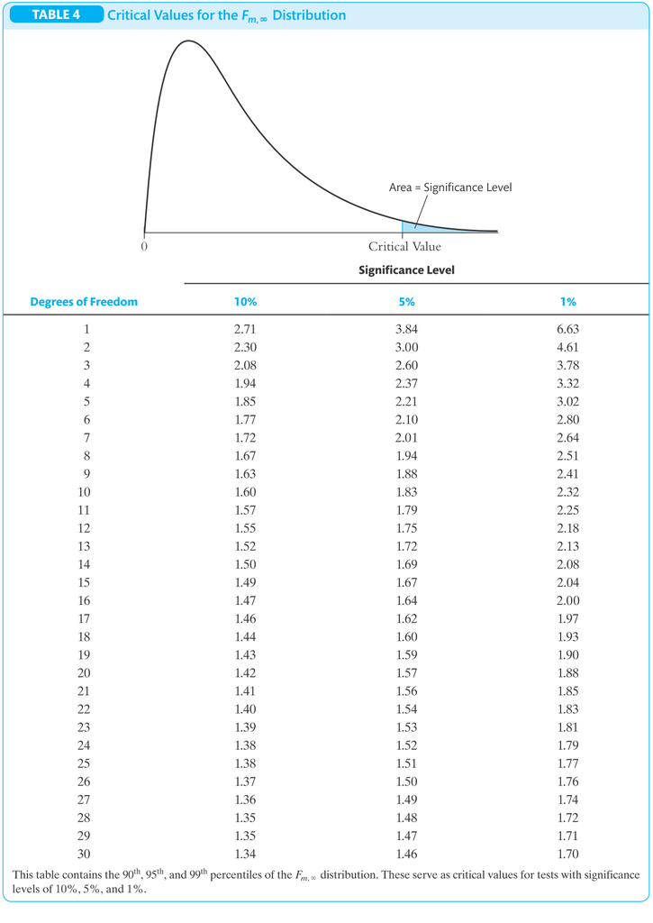

Source: Stock and Watson (2020) on p. 767

### Task c)

Test the hypothesis that the population coefficient of $STR$ and $Expn$ are identical based on the regression model estimated in Table 5 where the variable $W$ is defined such as $W \equiv STR + Expn$.

#### Approach 1

Approach 1 based on F-test

```r
# heteroskedasticity-robust F test
lin.hyp.02 <- linearHypothesis(lm.ct.res.04, c("STR=Expn"), white.adjust = "hc1")
lin.hyp.02
```

```
## Linear hypothesis test
##
## Hypothesis:
## STR - Expn = 0
##
## Model 1: restricted model
## Model 2: score ~ STR + PctEL + Expn
##
## Note: Coefficient covariance matrix supplied.
##
##   Res.Df Df      F Pr(>F)
## 1    417
## 2    416  1 0.3638 0.5467
```

Hypothesis

$$\begin{align}
H_0&: \quad \beta_{STR} = \beta_{Expn} \quad \quad \quad \text{vs.}
\\
H_1&: \quad \beta_{STR} \neq \beta_{Expn} \quad \quad \alpha = 5\%
\end{align}$$

*Add the hypothesis here!*

Test statistic

$$\begin{align}
F^{act}\left( 1, 416 \right) &= 0.364
\end{align}$$

*Add the test statistic here!*

$p$-value

$$\begin{align}
p-\text{value} &= Pr\left[ F\left( 1, 416 \right) > F^{act}\left(
1, 416 \right) \right] \\
p-\text{value} &= 0.547
\end{align}$$

*Add the $p$-value here!*

Decision

- No rejection of $H_0$ as

$$\begin{align}
F^{act}\left( 1, \infty \right) &< F^{crit \, 5\%}\left( 1,
\infty \right) \\
F^{act}\left( 1, \infty \right) &< 3.84
\end{align}$$

- No Rejection of $H_0$ as $p-\text{value} > 0.05$.

*Add the decision here!*

Note

- Check also the asymptotic critical value of the test statistic, i,e, $F\left(1,\infty\right)$, for $\alpha =5\%$.
- Use Table 4 in Stock and Watson (2020) on p. 767. (see below)

Critical value for the $\underline{F\left(m,\infty\right)}$

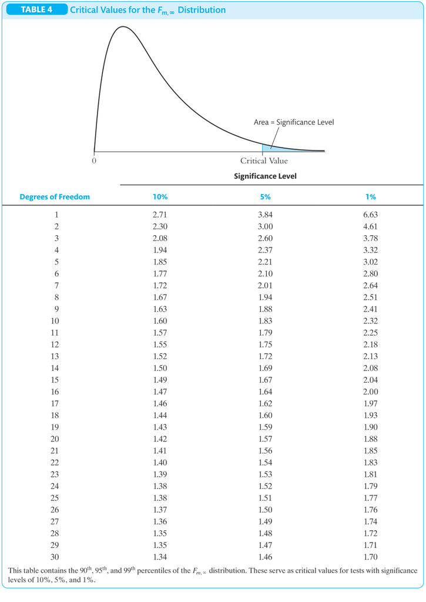

Source: Stock and Watson (2020) on p. 767

#### Approach 2

Approach 2 based on t-test

Construct variables

```r
# compute STR + Expn
cas.dat$W <- cas.dat$STR + cas.dat$Expn
```

Regression estimation

```r
# model 5
lm.ct.res.05 <- lm_ct_fun(score ~ STR + PctEL + W, data = cas.dat, hc.type="HC1")
lm.ct.res.05$ct
```

```
##
## t test of coefficients:
##
##                Estimate  Std. Error  t value Pr(>|t|)
## (Intercept) 649.5779466  15.4583437  42.0212  < 2e-16 ***
## STR          -0.2902670   0.4812443  -0.6032  0.54673
## PctEL        -0.6560227   0.0317844 -20.6398  < 2e-16 ***
## W             0.0038679   0.0015807   2.4469  0.01482 *
## ---
## Signif. codes:  0 '***' 0.001 '**' 0.01 '*' 0.05 '.' 0.1 ' ' 1
```

```
##
## ===============================
##            Model 1
## -------------------------------
## intercept  649.578 (15.458) ***
## STR         -0.290  (0.481)
## PctEL       -0.656  (0.032) ***
## W            0.004  (0.002) *
## -------------------------------
## R^2          0.437
## Adj. R^2     0.433
## Num. obs.  420
## SER         14.353
## ===============================
## *** p < 0.001; ** p < 0.01; * p < 0.05
```

Transformation

\begin{align} score_{i} &= \beta_{0} + \beta_{STR}STR_{i} + \beta_{PctEL}PctEL_{i} + \beta_{Expn}Expn_{i} + u_{i} \\ score_{i} &= \beta_{0} + \beta_{STR}STR_{i} + \beta_{PctEL}PctEL_{i} + \beta_{Expn}Expn_{i} + u_{i} \,\,\,\,\, | +\left(\beta_{Expn}STR_{i}-\beta_{Expn}STR_{i}\right) \\ score_{i} &= \beta_{0} + \beta_{STR}STR_{i} - \beta_{Expn}STR_{i} + \beta_{PctEL}PctEL_{i} + \beta_{Expn}Expn_{i} + \beta_{Expn}STR_{i} + u_{i} \\ score_{i} &= \beta_{0} + \left(\beta_{STR} - \beta_{Expn}\right) STR_{i} + \beta_{PctEL}PctEL_{i} + \beta_{Expn} \left(Expn_{i} + STR_{i}\right) + u_{i} \\ score_{i} &= \beta_{0} + \gamma_{1} STR_{i} + \beta_{PctEL}PctEL_{i} + \beta_{Expn} W_{i} + u_{i} \\ \end{align}

with

$$\begin{align}
\gamma_{1} \equiv \beta_{STR} - \beta_{Expn} \\
W \equiv STR + Expn
\end{align}$$

*Add your results here!*

Interpretation

$$\begin{align}
H_0&: \quad \beta_{STR} - \beta_{Expn} = 0 \\
H_0&: \quad \gamma_{1} = 0 \quad \text{vs.} \\
H_1&: \quad \gamma_{1} \neq 0 \quad \alpha = 5\%
\end{align}$$

*Add your results here!*

Based on test statistic

$$\begin{align}
t^{act} &= \frac{\hat{\gamma_{1}}^{act} -
0}{SE\left(\hat{\gamma_{1}}\right)} \\
t^{act} &= \frac{-0.29 - 0}{0.481} \\
t^{act} &= -0.603
\end{align}$$

*Add your results here!*

Conclusion:

- $|t^{act}| < 1.96$
- $H_0$ cannot be rejected at 5%.

*Add your results here!*

Based on $p$-value

*Add your results here!*

Conclusion:

- $p\text{-value}>0.05$
- $H_0$ cannot be rejected at 5% significance level.

Definition $p$-value:

- The p-value is the probability of observing a value of $\hat{\beta}$ at least as different from $\beta_{1,0}$ as the estimate actually computed $\left(\hat{\beta}^{act}_1\right)$, assuming that the null hypothesis is correct.
- Type I error, i.e. rejecting $H_0$ even if it is true.

*Add your results here!*

CDF Standard Normal Distribution

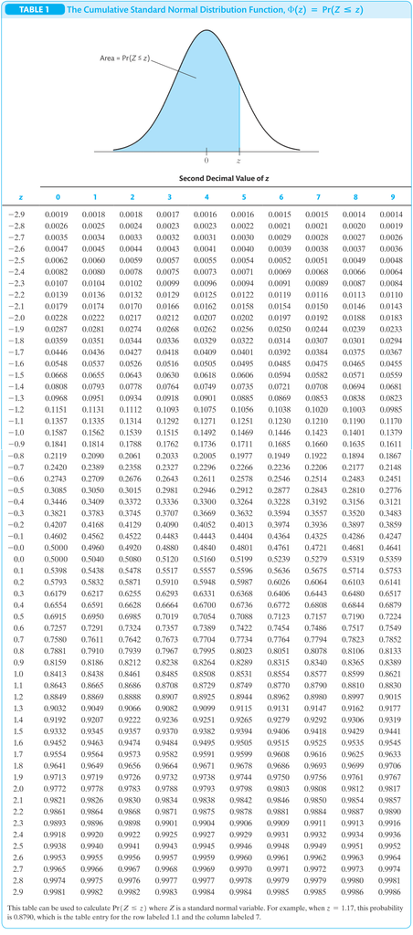

Source: Stock and Watson (2020), p. 763-764

An Illustration of the $p$-value

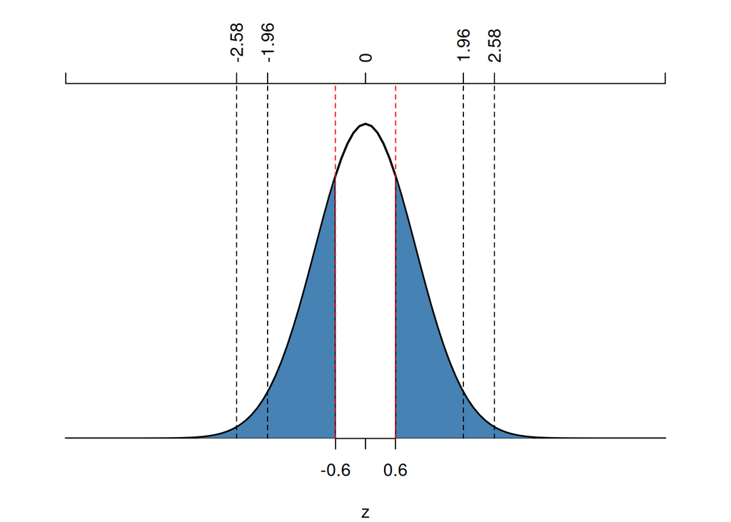

```r
ill_hyp_tes_fun(t.act=-0.603, test=c("two.sid"))
```

- $\gamma_{1}$: Not significantly different from zero (5 % level)
- $\Rightarrow$ Effect of $STR$ and $Expn$ are similar at (5 % level)

*Add your results here!*

#### Relationship

Relationship between Approach 1 and 2

Note, the relationship between $t$- and $F$-statistic.

$F$-statistic is is equal to the square of the $t$-statistic.

```r
# heteroskedasticity-robust t statistic
lm.ct.res.05$ct[2,3]^2
```

```
## [1] 0.3638012
```

```r
# heteroskedasticity-robust F statistic
lin.hyp.02$F[2]
```

```
## [1] 0.3638012
```

Back To *Start*